# R Notebook

## Análisis univariado

La principal herramienta de analisis univariado es un histograma

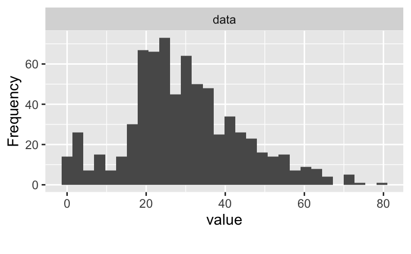

## Análisis bivariado

- Correlación

[figure not shown]

```r
#install.packages("ggplot2")
#install.packages("GGally")
library(ggplot2)
library(GGally)
ggpairs(titanic %>% select(-Name, -Ticket, - Cabin))
```

## Creación de funciones

Las funciones tienen las siguiente entructura:

function.name <- function(arguments) { computations on the arguments some other code }

```r
myFirstFun<-function(n)
{
  # Compute the square of integer `n`
  n*n
}
```

```r
sum.of.squares <- function(x,y) {
  x^2 + y^2
}
sum.of.squares(2,3)
```

```r
addPercent <- function(x){
 percent <- round(x * 100, digits = 1)
 result <- paste(percent, "%")
 return(result)
}

addPercent(5)
```

## Familia Apply

Realiza una misma funcion a todas las variables de una base de datos

```r
my.matrx <- as.data.frame(matrix(c(1:10, 11:20, 21:30), nrow = 10, ncol = 3))
my.matrx


sapply(my.matrx, mean)
sapply(my.matrx, sum)
```

```r
sapply(my.matrx, function (x)  x*2)
```

## Estructura de Control

Las estructuras de control en R le permiten controlar el flujo de ejecución de una serie de expresiones R. Básicamente, las estructuras de control le permiten poner algo de “lógica” en su código R, en lugar de simplemente ejecutar siempre el mismo código R cada vez. Las estructuras de control le permiten responder a entradas o características de los datos y ejecutar diferentes expresiones R en consecuencia.

### if else

La combinación if-else es probablemente la estructura de control más utilizada en R (o quizás en cualquier lenguaje). Esta estructura le permite probar una condición y actuar en función de si es verdadera o falsa.

Primer Caso: La condicion realiza una accion cuando es verdad y otra cuando es falso

```r
if(<condition>) {
        ## do something
}
else {
        ## do something else
}
```

Ejemplo

```r
quantity <-  25
# Set the is-else statement
if (quantity > 20) {
    print('You sold a lot!')
} else {
    print('Not enough for today')
}
```

Segundo caso: Existen diversas condiciones

```r
if(<condition1>) {
        ## do something
} else if(<condition2>)  {
        ## do something different
} else {
        ## do something different
}
```

Ejemplo

```r
quantity <-  10
# Create multiple condition statement
if (quantity <20) {
      print('Not enough for today')
} else if (quantity > 20  &quantity <= 30) {
     print('Average day')
} else {
      print('What a great day!')
}
```

### Loops: For.

Su objetivo es ejecutar un loop una cantidad fija de veces.

Primer Caso: “For” simple

```r
for (variable in secuencia) {
"expresion"
}
```

Ejemplo

```r
for(i in 1:10) {
         print(i)
 }
```

```r
 x <- c("a", "b", "c", "d")

 for(i in 1:4) {
         ## Print out each element of 'x'
         print(x[i])
 }
```

Segundo caso: “For”" anidado

Los loops anidados son comúnmente necesarios para estructuras de datos multidimensionales o jerárquicas (por ejemplo, matrices, listas). Sin embargo, ten cuidado con la anidación. Anidar más allá de 2 a 3 niveles a menudo dificulta la lectura / comprensión del código

```r
x <- matrix(1:6, 2, 3)

for(i in seq_len(nrow(x))) {
        for(j in seq_len(ncol(x))) {
                print(x[i, j])
        }
}
```

### Loops: While.

Su objetivo es ejecutar un loop cuando se cumpla una condición.Mientras que los bucles comienzan probando una condición. Si es cierto, ejecutan el cuerpo del bucle. Una vez que se ejecuta el cuerpo del bucle, la condición se prueba nuevamente, y así sucesivamente, hasta que la condición sea falsa, después de lo cual se cierra el bucle.

```r
while (condition) {
    expression
}
```

Ejemplo

```r
 count <- 0
 while(count < 10) {
         print(count)
         count <- count + 1
 }
```

Hay ciertas situaciones donde no voy a querer que el loop realize todas las iteraciones. En esos casos, me sirve realizar un Break o Next Statement.

### Break statement.

Es una forma de salida de la rutina.

```r
number <- 1:10

for (val in number)  {
  if (val == 7)  {
    print(paste("El loop terminara en el valor =  ", val))
    break
  }
  print(paste("El valor es :  ", val))
}
```

Ejemplo 2

```r
number <- 10

while (number > 0)  {
  if (number == 3)  {
    print(paste("Coming out from While loop Where number =  ", number))
    break
  }
  print(paste("Values are :  ", number))
  number = number - 1
}
```

### Next statement.

Permite seguir la interccion pero saltanto algun elemento sin terminarlo.

```r
x <- 1:5
for (val in x) {
if (val == 3){
next
}
print(val)
}
```

[clase de hoy](https://bookdown.org/rdpeng/rprogdatascience/regular-expressions.html#grep)